# Fair Speech Analysis

## Interview data overview

There are 73 interviews with black speakers (from CORAAL), and 51 interviews with white speakers (from VOC). These audio snippets total 39.76 hours, pre-matching.

## Propensity score matching

```r
# Matching algorithm
set.seed(100)
mod_match <- matchit(black_flag ~ age_bin_35 + age_bin_45 +
                       age_bin_55 + age_bin_65 + age_bin_75 + age_bin_85 + age_bin_95 +
                       age + female_flag + log_duration,
                     method = "nearest", distance = 'logit',
                     caliper = 0.001, data = reg_base)

dta_m <- match.data(mod_match)
matched_wer <- dta_m[,1:13]
write.csv(matched_wer, '../output/Matched_WER.csv', row.names = FALSE)
```

The resulting matching yields 2141 audio snippets from 73 black speakers, and 2141 audio snippets from 42 white speakers. These 4282 snippets, corresponding to 19.79 total hours of audio, are used for all ensuing analyses. Of these snippets, 44% have male speakers, average snippet duration is 17 seconds, and average speaker age is 45 years.

## Confirming covariate balance

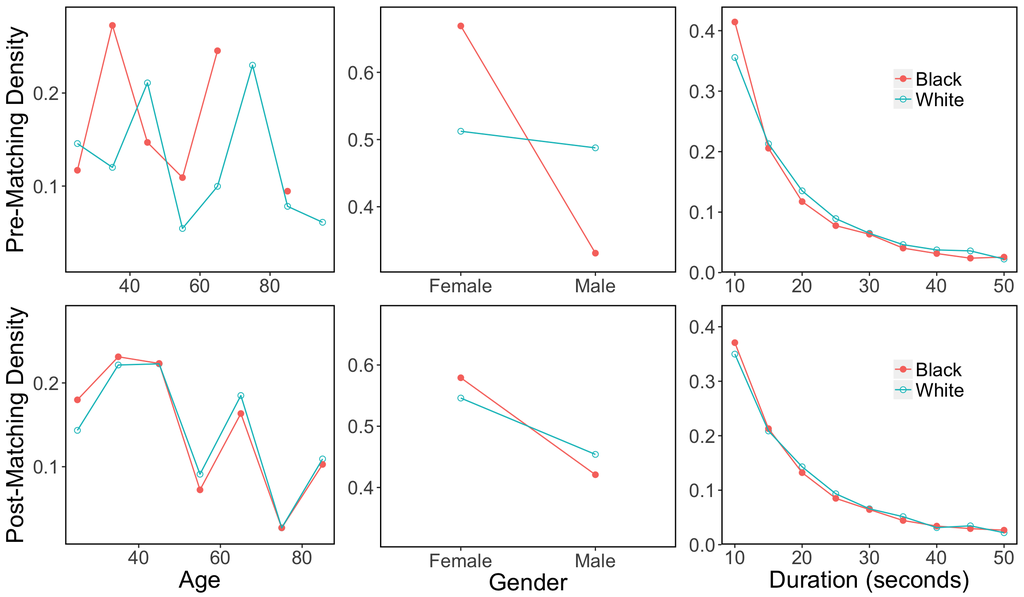

## Average Word Error Rate by ASR Service

Across all ASRs, the average WER for transcriptions of black speakers is 0.35, nearly double the WER for white speakers 0.19. The maximum standard error across all ASRs and both races was 0.005.

```
##    black_flag   variable value.Mean    value.SE asr_factor speaker_factor
## 1           0  apple_wer  0.2310982 0.003297656      Apple          White
## 2           1  apple_wer  0.4485088 0.005382573      Apple          Black
## 5           0    ibm_wer  0.2008842 0.003033999        IBM          White
## 6           1    ibm_wer  0.3843038 0.004826726        IBM          Black
## 9           0 google_wer  0.1861031 0.003106455     Google          White
## 10          1 google_wer  0.3129312 0.004684935     Google          Black
## 13          0 amazon_wer  0.1627995 0.002687140     Amazon          White
## 14          1 amazon_wer  0.3138366 0.004271932     Amazon          Black
## 17          0   msft_wer  0.1498971 0.002817473  Microsoft          White
## 18          1   msft_wer  0.2738680 0.004114367  Microsoft          Black
```

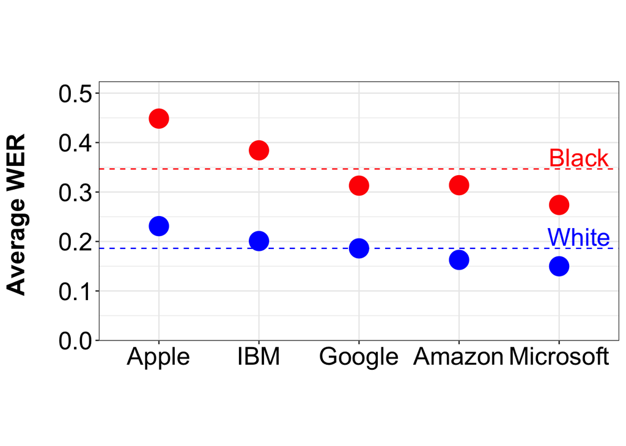

## Complementary CDF of Word Error Rates

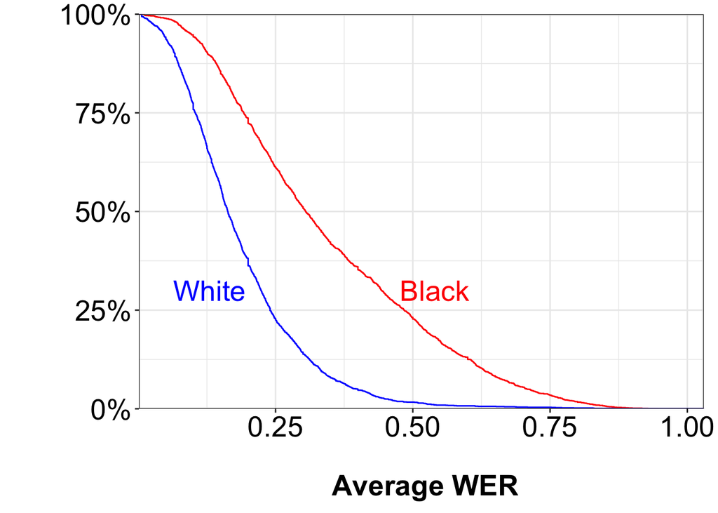

## WERs by location of interview

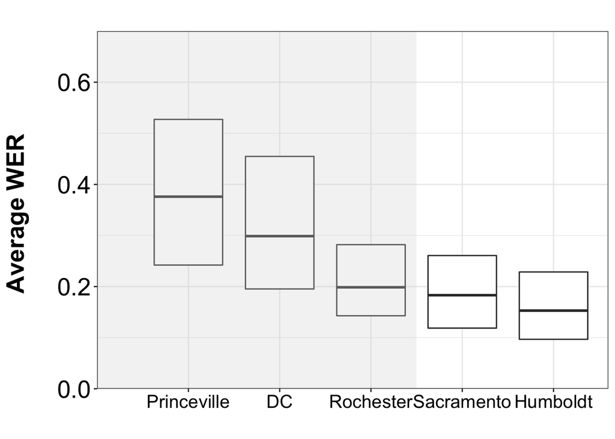

## Dialect Density Measure correlates with WER

DDM summary:

```
##     n avg_wordcount avg_phon_count avg_gram_count   avg_ddm
## 1 150         47.08       3.466667      0.4533333 0.1092695
```

DDM by group:

```
## # A tibble: 3 x 6
##   source          n    avg      se  lower  upper
##   <fct>       <int>  <dbl>   <dbl>  <dbl>  <dbl>
## 1 Rochester      50 0.0466 0.00703 0.0326 0.0607
## 2 DC             50 0.0875 0.0108  0.0660 0.109
## 3 Princeville    50 0.194  0.0168  0.160  0.227
```

```
## # A tibble: 2 x 6
##   female_flag     n    avg      se  lower upper
##         <int> <int>  <dbl>   <dbl>  <dbl> <dbl>
## 1           0    52 0.134  0.0161  0.102  0.166
## 2           1    98 0.0963 0.00993 0.0764 0.116
```

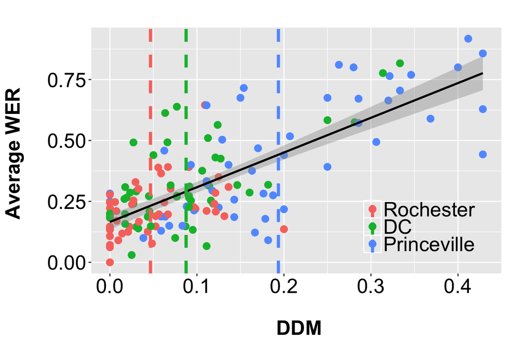

```
##
## Call:
## lm(formula = avg_wer ~ 1 + I(phon_count/wordcount) + I(gram_count/wordcount) +
##     age + female_flag + duration, data = complete_data)
##
## Residuals:
##      Min       1Q   Median       3Q      Max
## -0.33408 -0.08663 -0.01217  0.07695  0.35981
##
## Coefficients:
##                           Estimate Std. Error t value Pr(>|t|)
## (Intercept)              0.2274994  0.0386677   5.883 2.70e-08 ***
## I(phon_count/wordcount)  1.4834968  0.1364827  10.869  < 2e-16 ***
## I(gram_count/wordcount)  1.8023708  0.3913495   4.606 8.97e-06 ***
## age                     -0.0014761  0.0005875  -2.512   0.0131 *
## female_flag             -0.0140929  0.0237808  -0.593   0.5544
## duration                 0.0001541  0.0010021   0.154   0.8780
## ---
## Signif. codes:  0 '***' 0.001 '**' 0.01 '*' 0.05 '.' 0.1 ' ' 1
##
## Residual standard error: 0.1344 on 144 degrees of freedom
## Multiple R-squared:  0.5745, Adjusted R-squared:  0.5597
## F-statistic: 38.88 on 5 and 144 DF,  p-value: < 2.2e-16
```

## Regressions separated by gender

As an example, for the average 45-year-old speaking for 30 seconds, Google’s ASR performs as follows:

- Black man: WER = 0.37
- Black woman: WER = 0.23
- White man: WER = 0.19
- White woman: WER = 0.14